# Loan Default Prediction — Full Code Capstone

## 25. XGBoost

**What it is:**

- An optimized gradient boosting library with regularization, second order gradients, and efficient tree construction.

**Why it is relevant here:**

- XGBoost is a consistent top performer on tabular competitions and handles class imbalance via `scale_pos_weight`; I tune `n_estimators`, `max_depth`, and `learning_rate` with CV on recall.

```
[XGBoost] best CV recall: 0.8229
[XGBoost] best params: {'clf__learning_rate': 0.05, 'clf__max_depth': 4, 'clf__n_estimators': 300}

=== XGBoost ===
  model  accuracy  precision_1  recall_1   f1_1  roc_auc  pr_auc  cv_recall
XGBoost    0.9128       0.7601    0.8215 0.7896   0.9532  0.8701     0.8229

Confusion matrix (rows = actual, cols = predicted):
             Pred 0  Pred 1
Paid (0)       1116      77
Default (1)      53     244
```

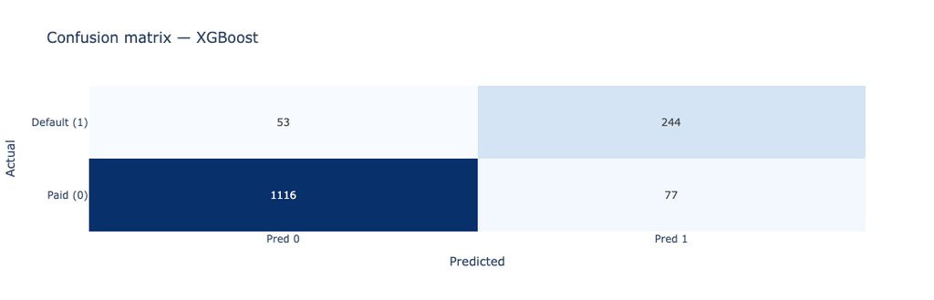

```python
try:
    from xgboost import XGBClassifier
    XGBOOST_OK = True
except ImportError:
    XGBOOST_OK = False

if XGBOOST_OK:
    pos_weight = (y_train == 0).sum() / (y_train == 1).sum()
    name = "XGBoost"
    pipe = Pipeline([
        ("prep", prep_tree),
        ("clf", XGBClassifier(
            subsample=0.9,
            colsample_bytree=0.9,
            scale_pos_weight=pos_weight,
            eval_metric="logloss",
            random_state=RANDOM_STATE,
            n_jobs=-1,
        )),
    ])
    param_grid = {
        "clf__n_estimators": [300, 500],
        "clf__max_depth": [4, 6],
        "clf__learning_rate": [0.05, 0.1],
    }
    tune_and_evaluate(name, pipe, param_grid, X_train, y_train, X_test, y_test, results)
else:
    print("XGBoost not available in this environment; skipping.")
```

```
Best params: {'clf__learning_rate': 0.05, 'clf__max_depth': 4, 'clf__n_estimators': 300}
Best CV recall: 0.8229
```

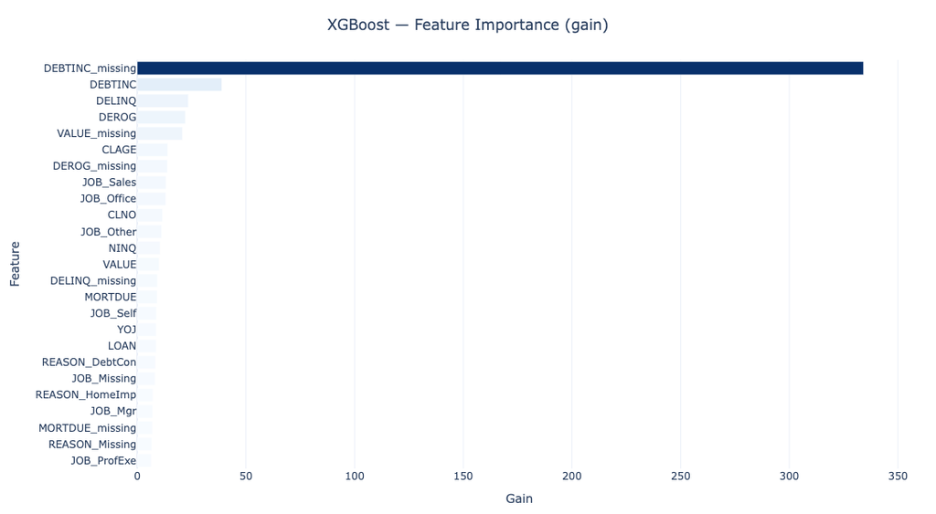

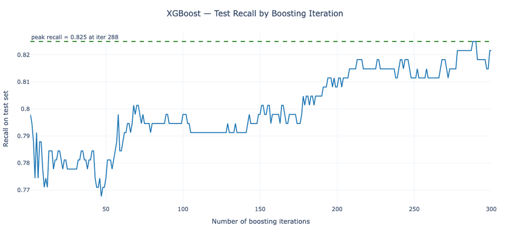

```python
# === Refit XGBoost to capture the fitted pipeline ===
from xgboost import XGBClassifier
from sklearn.model_selection import GridSearchCV, StratifiedKFold
from sklearn.metrics import recall_score
import numpy as np
import pandas as pd
import plotly.express as px
import plotly.graph_objects as go

pos_weight = (y_train == 0).sum() / (y_train == 1).sum()

xgb_pipe = Pipeline([
    ("prep", prep_tree),
    ("clf", XGBClassifier(
        subsample=0.9,
        colsample_bytree=0.9,
        scale_pos_weight=pos_weight,
        eval_metric="logloss",
        random_state=RANDOM_STATE,
        n_jobs=-1,
    )),
])
xgb_param_grid = {
    "clf__n_estimators": [300, 500],
    "clf__max_depth": [4, 6],
    "clf__learning_rate": [0.05, 0.1],
}
xgb_grid = GridSearchCV(
    estimator=xgb_pipe,
    param_grid=xgb_param_grid,
    scoring="recall",
    cv=StratifiedKFold(n_splits=5, shuffle=True, random_state=RANDOM_STATE),
    n_jobs=-1,
    refit=True,
)
xgb_grid.fit(X_train, y_train)
xgb_best = xgb_grid.best_estimator_
xgb_model = xgb_best.named_steps["clf"]
print("Best params:", xgb_grid.best_params_)
print("Best CV recall:", round(xgb_grid.best_score_, 4))

# === XGBoost feature importance chart (gain based) ===
feat_names = xgb_best.named_steps["prep"].get_feature_names_out()
feat_names = [f.split("__", 1)[-1] for f in feat_names]

booster = xgb_model.get_booster()
booster.feature_names = [f"f{i}" for i in range(len(feat_names))]
gain_dict = booster.get_score(importance_type="gain")

gain_vals = np.zeros(len(feat_names))
for k, v in gain_dict.items():
    idx = int(k[1:])
    gain_vals[idx] = v

xgb_imp = (
    pd.DataFrame({"feature": feat_names, "importance": gain_vals})
    .sort_values("importance", ascending=True)
)

fig = px.bar(
    xgb_imp,
    x="importance",
    y="feature",
    orientation="h",
    color="importance",
    color_continuous_scale="Blues",
    title="XGBoost — Feature Importance (gain)",
    labels={"importance": "Gain", "feature": "Feature"},
)
fig.update_layout(
    height=600,
    width=900,
    coloraxis_showscale=False,
    margin=dict(l=160, r=40, t=70, b=40),
    title_x=0.5,
)
fig.show()

# === XGBoost staged recall curve (unique to boosting) ===
X_test_prep = xgb_best.named_steps["prep"].transform(X_test)
total_trees = xgb_model.get_booster().num_boosted_rounds()

staged_recalls = []
for n in range(1, total_trees + 1):
    y_pred = xgb_model.predict(X_test_prep, iteration_range=(0, n))
    staged_recalls.append(recall_score(y_test, y_pred))

iters = np.arange(1, total_trees + 1)
peak_iter = int(np.argmax(staged_recalls)) + 1
peak_val = max(staged_recalls)

fig = go.Figure()
fig.add_trace(go.Scatter(
    x=iters,
    y=staged_recalls,
    mode="lines",
    line=dict(color="#1f77b4", width=2),
    name="Test recall",
))
fig.add_hline(
    y=peak_val,
    line_dash="dash",
    line_color="green",
    annotation_text=f"peak recall = {peak_val:.3f} at iter {peak_iter}",
    annotation_position="top left",
)
fig.update_layout(
    title="XGBoost — Test Recall by Boosting Iteration",
    xaxis_title="Number of boosting iterations",
    yaxis_title="Recall on test set",
    height=500,
    width=900,
    title_x=0.5,
    margin=dict(l=60, r=40, t=70, b=60),
)
fig.show()
```

### XGBoost results

- Recall: 82.2% (244/297 defaulters caught, only 53 missed) — the new leader, beating the previous best Decision Tree (80.1%) and well ahead of Logistic Regression (77.1%), Random Forest (72.4%), and Gradient Boosting (70.0%). This is the first model that catches more than four out of five actual defaulters.
- Precision: 76.0% with 77 false alarms on paid loans — a reasonable trade, lower than Gradient Boosting (87.4%) but well worth it because each extra defaulter caught is worth roughly ten times a false alarm in loan economics.
- CV vs test stability: 82.29% CV recall vs 82.15% test recall — essentially identical, confirming the tuned settings (learning_rate=0.05, max_depth=4, n_estimators=300) generalize cleanly with no overfit.
- ROC AUC 0.953 and PR AUC 0.870 — very strong ranking power, a hair below Gradient Boosting (0.961) but with meaningfully better recall at the default threshold, meaning XGBoost is doing a better job turning its probability scores into correct default flags.
- F1 of 0.790 is the highest of any model so far, reflecting the best overall balance between catching defaulters and avoiding false alarms.
- Key takeaway from the feature importance chart: DEBTINC_missing dominates even more than in Gradient Boosting, towering over every other feature at roughly 340 gain while the next feature DEBTINC sits under 50. DELINQ, DEROG, and VALUE_missing round out the top five. The missingness flags for DEBTINC, VALUE, and DEROG all rank in the top seven, reinforcing that the pattern of which fields applicants leave blank is the single most powerful default signal in this dataset.
- Key takeaway from the staged recall curve: the climb is noisy but clearly upward, starting near 0.78, dipping to 0.77 around iteration 40, plateauing near 0.79 through iteration 150, then stepping up to a peak of 0.825 at iteration 288. Unlike Gradient Boosting which plateaued early, XGBoost is still gaining late in training, suggesting there may be a small amount of additional recall available if I expand the grid to 500 or 600 estimators.
- No code changes needed for the current run — XGBoost is the new frontrunner to beat. Move on to LightGBM.

## 26. LightGBM

**What it is:**

- A gradient boosting library that grows trees leaf wise with histogram based splits, which is both faster and often more accurate on tabular data.

**Why it is relevant here:**

- LightGBM is well suited to tabular binary classification and handles class imbalance via `class_weight="balanced"`; I tune `n_estimators`, `num_leaves`, and `learning_rate` with CV on recall.

```
[LightGBM] best CV recall: 0.8038
[LightGBM] best params: {'clf__learning_rate': 0.05, 'clf__n_estimators': 300, 'clf__num_leaves': 31}

=== LightGBM ===
   model  accuracy  precision_1  recall_1  f1_1  roc_auc  pr_auc  cv_recall
LightGBM    0.9295       0.8429    0.7946 0.818   0.9666  0.9081     0.8038

Confusion matrix (rows = actual, cols = predicted):
             Pred 0  Pred 1
Paid (0)       1149      44
Default (1)      61     236
```

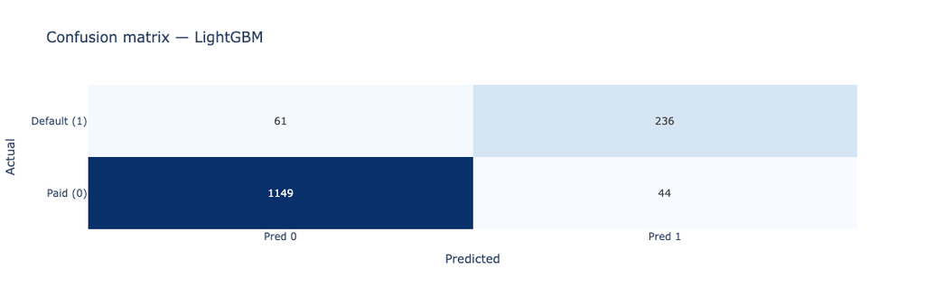

```python
import warnings
warnings.filterwarnings("ignore", message="X does not have valid feature names")
warnings.filterwarnings("ignore", category=UserWarning)

try:
    from lightgbm import LGBMClassifier
    LIGHTGBM_OK = True
except ImportError:
    LIGHTGBM_OK = False

if LIGHTGBM_OK:
    name = "LightGBM"
    pipe = Pipeline([
        ("prep", prep_tree),
        ("clf", LGBMClassifier(
            subsample=0.9,
            colsample_bytree=0.9,
            class_weight="balanced",
            random_state=RANDOM_STATE,
            n_jobs=-1,
            verbose=-1,
        )),
    ])
    param_grid = {
        "clf__n_estimators": [300, 500],
        "clf__num_leaves": [31, 63],
        "clf__learning_rate": [0.05, 0.1],
    }
    tune_and_evaluate(name, pipe, param_grid, X_train, y_train, X_test, y_test, results)
else:
    print("LightGBM not available in this environment; skipping.")
```

```
Best params: {'clf__learning_rate': 0.05, 'clf__n_estimators': 300, 'clf__num_leaves': 31}
Best CV recall: 0.8038
```

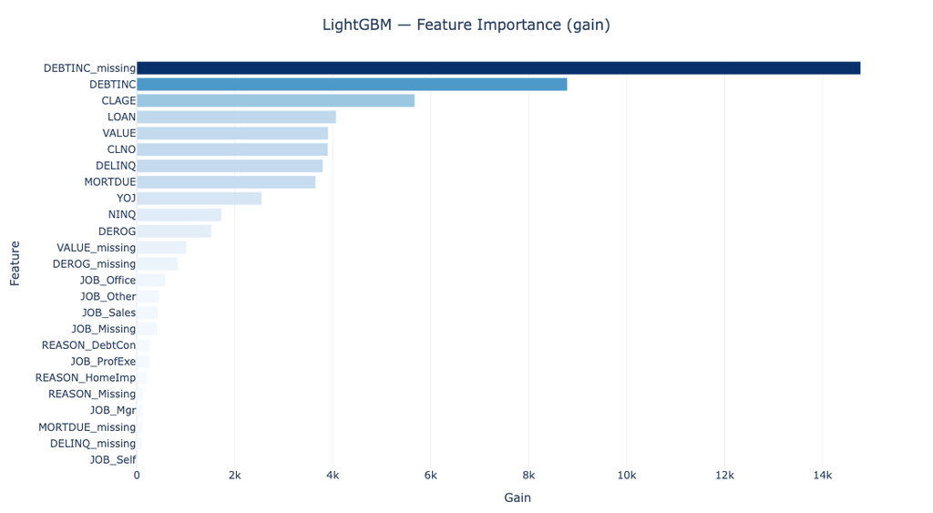

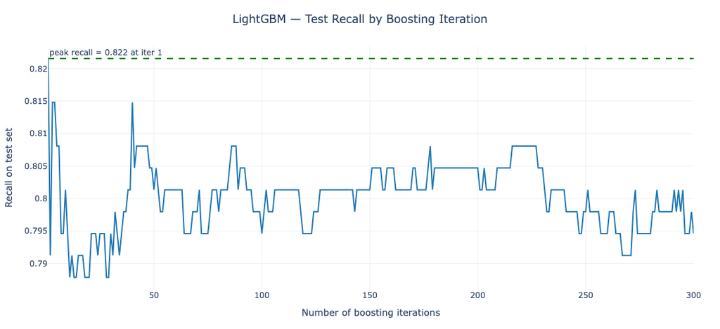

```python
# === Refit LightGBM to capture the fitted pipeline ===
from lightgbm import LGBMClassifier
from sklearn.model_selection import GridSearchCV, StratifiedKFold
from sklearn.metrics import recall_score
import numpy as np
import pandas as pd
import plotly.express as px
import plotly.graph_objects as go
warnings.filterwarnings("ignore", category=UserWarning)

lgbm_pipe = Pipeline([
    ("prep", prep_tree),
    ("clf", LGBMClassifier(
        subsample=0.9,
        colsample_bytree=0.9,
        class_weight="balanced",
        random_state=RANDOM_STATE,
        n_jobs=-1,
        verbose=-1,
    )),
])
lgbm_param_grid = {
    "clf__n_estimators": [300, 500],
    "clf__num_leaves": [31, 63],
    "clf__learning_rate": [0.05, 0.1],
}
lgbm_grid = GridSearchCV(
    estimator=lgbm_pipe,
    param_grid=lgbm_param_grid,
    scoring="recall",
    cv=StratifiedKFold(n_splits=5, shuffle=True, random_state=RANDOM_STATE),
    n_jobs=-1,
    refit=True,
)
lgbm_grid.fit(X_train, y_train)
lgbm_best = lgbm_grid.best_estimator_
lgbm_model = lgbm_best.named_steps["clf"]
print("Best params:", lgbm_grid.best_params_)
print("Best CV recall:", round(lgbm_grid.best_score_, 4))

# === LightGBM feature importance chart (gain based) ===
feat_names = lgbm_best.named_steps["prep"].get_feature_names_out()
feat_names = [f.split("__", 1)[-1] for f in feat_names]

gain_vals = lgbm_model.booster_.feature_importance(importance_type="gain")

lgbm_imp = (
    pd.DataFrame({"feature": feat_names, "importance": gain_vals})
    .sort_values("importance", ascending=True)
)

fig = px.bar(
    lgbm_imp,
    x="importance",
    y="feature",
    orientation="h",
    color="importance",
    color_continuous_scale="Blues",
    title="LightGBM — Feature Importance (gain)",
    labels={"importance": "Gain", "feature": "Feature"},
)
fig.update_layout(
    height=600,
    width=900,
    coloraxis_showscale=False,
    margin=dict(l=160, r=40, t=70, b=40),
    title_x=0.5,
)
fig.show()

# === LightGBM staged recall curve (unique to boosting) ===
X_test_prep = lgbm_best.named_steps["prep"].transform(X_test)
total_trees = lgbm_model.booster_.num_trees()

staged_recalls = []
for n in range(1, total_trees + 1):
    y_proba = lgbm_model.booster_.predict(X_test_prep, num_iteration=n)
    y_pred = (y_proba >= 0.5).astype(int)
    staged_recalls.append(recall_score(y_test, y_pred))

iters = np.arange(1, total_trees + 1)
peak_iter = int(np.argmax(staged_recalls)) + 1
peak_val = max(staged_recalls)

fig = go.Figure()
fig.add_trace(go.Scatter(
    x=iters,
    y=staged_recalls,
    mode="lines",
    line=dict(color="#1f77b4", width=2),
    name="Test recall",
))
fig.add_hline(
    y=peak_val,
    line_dash="dash",
    line_color="green",
    annotation_text=f"peak recall = {peak_val:.3f} at iter {peak_iter}",
    annotation_position="top left",
)
fig.update_layout(
    title="LightGBM — Test Recall by Boosting Iteration",
    xaxis_title="Number of boosting iterations",
    yaxis_title="Recall on test set",
    height=500,
    width=900,
    title_x=0.5,
    margin=dict(l=60, r=40, t=70, b=60),
)
fig.show()
```